# Okesola Moses_Hacthatons2A_project

**Import Necessary Libraries**

```python
import pandas as pd
import numpy as np
import matplotlib.pyplot as plt
import seaborn as sns
from sklearn.metrics import (
    f1_score,
    accuracy_score,
    recall_score,
    precision_score,
    confusion_matrix,
    roc_auc_score,
    make_scorer,
    ConfusionMatrixDisplay,
)
from sklearn import metrics
from sklearn.model_selection import train_test_split, cross_val_score
from sklearn.preprocessing import StandardScaler, LabelEncoder, OneHotEncoder
from sklearn.preprocessing import StandardScaler
from sklearn.neighbors import KNeighborsClassifier
from sklearn.svm import SVC
from sklearn.model_selection import GridSearchCV
from sklearn.model_selection import RandomizedSearchCV
from sklearn.pipeline import Pipeline
from sklearn.impute import SimpleImputer
from sklearn.compose import ColumnTransformer
from sklearn.linear_model import LogisticRegression
from sklearn.tree import DecisionTreeClassifier
from sklearn.ensemble import (
    AdaBoostClassifier, GradientBoostingClassifier, RandomForestClassifier)
from xgboost import XGBClassifier

import warnings
warnings.filterwarnings("ignore")
```

**Loading the Dataset**

```python
train_data = pd.read_csv("HC2_Train_set.csv" )
test_data = pd.read_csv("HC2_Test_set.csv")
```

**Data Overview**

**The first five rows of the Train set and Test set**

```python
train_data.head().T
```

|  | 0 | 1 | 2 | 3 | 4 |
| --- | --- | --- | --- | --- | --- |
| ID | 72199369 | 14257956 | 66216451 | 46974169 | 46725961 |
| loan_amnt | 9000 | 18000 | 16000 | 25000 | 17000 |
| loan_term | 3 years | 3 years | 3 years | 3 years | 3 years |
| interest_rate | 9.17 | 13.65 | 7.26 | 13.99 | 6.39 |
| loan_grade | B | C | A | C | A |
| loan_subgrade | B2 | C1 | A4 | C4 | A2 |
| job_experience | <5 Years | <5 Years | <5 Years | NaN | 10+ years |
| home_ownership | OWN | OWN | MORTGAGE | MORTGAGE | MORTGAGE |
| annual_income | 85000.0 | 64000.0 | 150000.0 | 59800.0 | 72000.0 |
| income_verification_status | Not Verified | Verified | Source Verified | Verified | Source Verified |
| loan_purpose | debt_consolidation | debt_consolidation | debt_consolidation | debt_consolidation | credit_card |
| state_code | NC | SC | TX | MO | TX |
| debt_to_income | 26.68 | 31.67 | 19.7 | 37.39 | 8.92 |
| delinq_2yrs | 0.0 | 0.0 | 2.0 | 0.0 | 0.0 |
| public_records | 0.0 | 1.0 | 0.0 | 0.0 | 0.0 |
| revolving_balance | 39519 | 9783 | 13641 | 35020 | 23990 |
| total_acc | 20.0 | 24.0 | 27.0 | 35.0 | 26.0 |
| interest_receive | 59.6 | 3348.25 | 276.69 | 1106.72 | 725.29 |
| application_type | INDIVIDUAL | INDIVIDUAL | INDIVIDUAL | INDIVIDUAL | INDIVIDUAL |
| last_week_pay | 4.0 | 95.0 | 13.0 | 17.0 | 39.0 |
| total_current_balance | 95493.0 | 185433.0 | 180519.0 | 183208.0 | 23990.0 |
| total_revolving_limit | 84100.0 | 13500.0 | 19300.0 | 55400.0 | 81300.0 |
| default | 0 | 0 | 0 | 0 | 0 |

```python
test_data.head().T
```

|  | 0 | 1 | 2 | 3 | 4 |
| --- | --- | --- | --- | --- | --- |
| ID | 4855329 | 66862420 | 3637416 | 53682249 | 53937165 |
| loan_amnt | 12000 | 12000 | 15000 | 12000 | 20150 |
| loan_term | 3 years | 3 years | 3 years | 3 years | 3 years |
| interest_rate | 15.31 | 7.26 | 14.33 | 9.99 | 11.53 |
| loan_grade | C | A | C | B | B |
| loan_subgrade | C2 | A4 | C1 | B3 | B5 |
| job_experience | <5 Years | 10+ years | 6-10 years | 6-10 years | <5 Years |
| home_ownership | MORTGAGE | MORTGAGE | MORTGAGE | RENT | RENT |
| annual_income | 73400.0 | 105000.0 | 50000.0 | 37000.0 | 75000.0 |
| income_verification_status | Not Verified | Not Verified | Verified | Source Verified | Source Verified |
| loan_purpose | debt_consolidation | credit_card | debt_consolidation | credit_card | debt_consolidation |
| state_code | CA | VA | TX | NJ | CA |
| debt_to_income | 14.62 | 11.38 | 28.15 | 34.32 | 26.74 |
| delinq_2yrs | 0.0 | 0.0 | 0.0 | 0.0 | 1.0 |
| public_records | 0.0 | 0.0 | 1.0 | 0.0 | 0.0 |
| revolving_balance | 22156 | 7592 | 17983 | 12262 | 8251 |
| total_acc | 30.0 | 14.0 | 19.0 | 18.0 | 11.0 |
| interest_receive | 2290.24 | 202.68 | 1166.24 | 635.06 | 1232.84 |
| application_type | INDIVIDUAL | INDIVIDUAL | INDIVIDUAL | INDIVIDUAL | INDIVIDUAL |
| last_week_pay | 87.0 | 13.0 | 30.0 | 35.0 | 31.0 |
| total_current_balance | 128098.0 | 269396.0 | 220135.0 | 39436.0 | 52764.0 |
| total_revolving_limit | 25800.0 | 23600.0 | 34100.0 | 21700.0 | 12000.0 |

**The last five rows of the Train set and Test set**

```python
train_data.tail().T
```

|  | 93169 | 93170 | 93171 | 93172 | 93173 |
| --- | --- | --- | --- | --- | --- |
| ID | 65577252 | 836021 | 33058720 | 4060472 | 3628127 |
| loan_amnt | 3200 | 3500 | 8000 | 35000 | 10000 |
| loan_term | 3 years | 3 years | 3 years | 3 years | 3 years |
| interest_rate | 7.26 | 5.42 | 13.98 | 17.77 | 15.8 |
| loan_grade | A | A | C | D | C |
| loan_subgrade | A4 | A1 | C3 | D1 | C3 |
| job_experience | <5 Years | NaN | 10+ years | <5 Years | <5 Years |
| home_ownership | RENT | MORTGAGE | RENT | RENT | RENT |
| annual_income | 85000.0 | 57550.0 | 148531.5 | 100000.0 | 60000.0 |
| income_verification_status | Not Verified | Not Verified | Source Verified | Verified | Verified |
| loan_purpose | debt_consolidation | other | credit_card | debt_consolidation | debt_consolidation |
| state_code | FL | FL | AK | CA | NJ |
| debt_to_income | 17.11 | 22.64 | 13.04 | 17.22 | 11.83 |
| delinq_2yrs | 0.0 | 0.0 | 1.0 | 0.0 | 0.0 |
| public_records | 0.0 | 0.0 | 0.0 | 0.0 | 0.0 |
| revolving_balance | 7924 | 10174 | 5391 | 24609 | 11285 |
| total_acc | 38.0 | 24.0 | 25.0 | 45.0 | 7.0 |
| interest_receive | 55.34 | 299.67 | 1150.58 | 5764.58 | 2279.36 |
| application_type | INDIVIDUAL | INDIVIDUAL | INDIVIDUAL | INDIVIDUAL | INDIVIDUAL |
| last_week_pay | 13.0 | 161.0 | 65.0 | 56.0 | 104.0 |
| total_current_balance | 64635.0 | NaN | 94596.0 | 33759.0 | 25594.0 |
| total_revolving_limit | 47600.0 | NaN | 6500.0 | 34900.0 | 12300.0 |
| default | 0 | 1 | 0 | 1 | 0 |

```python
test_data.tail().T
```

|  | 39928 | 39929 | 39930 | 39931 | 39932 |
| --- | --- | --- | --- | --- | --- |
| ID | 57779318 | 59742362 | 72657145 | 15220189 | 21810584 |
| loan_amnt | 5000 | 1800 | 15200 | 14425 | 27000 |
| loan_term | 3 years | 3 years | 3 years | 5 years | 5 years |
| interest_rate | 8.18 | 11.53 | 13.44 | 18.92 | 20.2 |
| loan_grade | B | B | C | D | E |
| loan_subgrade | B1 | B5 | C3 | D4 | E3 |
| job_experience | 10+ years | 6-10 years | 10+ years | <5 Years | <5 Years |
| home_ownership | MORTGAGE | MORTGAGE | MORTGAGE | MORTGAGE | MORTGAGE |
| annual_income | 65000.0 | 55000.0 | 78000.0 | 38000.0 | 62000.0 |
| income_verification_status | Source Verified | Source Verified | Not Verified | Not Verified | Source Verified |
| loan_purpose | home_improvement | home_improvement | credit_card | credit_card | debt_consolidation |
| state_code | MI | AZ | TX | IN | FL |
| debt_to_income | 13.09 | 25.44 | 19.4 | 17.4 | 24.12 |
| delinq_2yrs | 0.0 | 0.0 | 0.0 | 0.0 | 1.0 |
| public_records | 5.0 | 1.0 | 0.0 | 1.0 | 0.0 |
| revolving_balance | 6731 | 11092 | 19688 | 10805 | 17795 |
| total_acc | 24.0 | 38.0 | 26.0 | 29.0 | 17.0 |
| interest_receive | 187.27 | 81.24 | 0.0 | 4268.8 | 7436.41 |
| application_type | INDIVIDUAL | INDIVIDUAL | INDIVIDUAL | INDIVIDUAL | INDIVIDUAL |
| last_week_pay | 26.0 | 26.0 | NaN | 96.0 | 78.0 |
| total_current_balance | 14422.0 | 243469.0 | 145370.0 | 106449.0 | 55787.0 |
| total_revolving_limit | 26100.0 | 29200.0 | 45400.0 | 19700.0 | 33500.0 |

**Check the shape of the Train and Test set**

```python
train_data.shape
```

```
(93174, 23)
```

There are 93174 rows and 23 columns in the Train set.

```python
test_data.shape
```

```
(39933, 22)
```

There are 39933 rows and 22 columns in the Test set.

**Check the data types of the columns for the Training and Testing dataset**

```python
train_data.info()
```

```
<class 'pandas.core.frame.DataFrame'>
RangeIndex: 93174 entries, 0 to 93173
Data columns (total 23 columns):
 #   Column                      Non-Null Count  Dtype
---  ------                      --------------  -----
 0   ID                          93174 non-null  int64
 1   loan_amnt                   93174 non-null  int64
 2   loan_term                   93174 non-null  object
 3   interest_rate               93174 non-null  float64
 4   loan_grade                  93174 non-null  object
 5   loan_subgrade               93174 non-null  object
 6   job_experience              88472 non-null  object
 7   home_ownership              93174 non-null  object
 8   annual_income               93173 non-null  float64
 9   income_verification_status  93174 non-null  object
 10  loan_purpose                93174 non-null  object
 11  state_code                  93174 non-null  object
 12  debt_to_income              93174 non-null  float64
 13  delinq_2yrs                 93172 non-null  float64
 14  public_records              93172 non-null  float64
 15  revolving_balance           93174 non-null  int64
 16  total_acc                   93172 non-null  float64
 17  interest_receive            93174 non-null  float64
 18  application_type            93174 non-null  object
 19  last_week_pay               91250 non-null  float64
 20  total_current_balance       85788 non-null  float64
 21  total_revolving_limit       85788 non-null  float64
 22  default                     93174 non-null  int64
dtypes: float64(10), int64(4), object(9)
memory usage: 16.3+ MB
```

```python
test_data.info()
```

```
<class 'pandas.core.frame.DataFrame'>
RangeIndex: 39933 entries, 0 to 39932
Data columns (total 22 columns):
 #   Column                      Non-Null Count  Dtype
---  ------                      --------------  -----
 0   ID                          39933 non-null  int64
 1   loan_amnt                   39933 non-null  int64
 2   loan_term                   39933 non-null  object
 3   interest_rate               39933 non-null  float64
 4   loan_grade                  39933 non-null  object
 5   loan_subgrade               39933 non-null  object
 6   job_experience              37844 non-null  object
 7   home_ownership              39933 non-null  object
 8   annual_income               39933 non-null  float64
 9   income_verification_status  39933 non-null  object
 10  loan_purpose                39933 non-null  object
 11  state_code                  39933 non-null  object
 12  debt_to_income              39933 non-null  float64
 13  delinq_2yrs                 39932 non-null  float64
 14  public_records              39932 non-null  float64
 15  revolving_balance           39933 non-null  int64
 16  total_acc                   39932 non-null  float64
 17  interest_receive            39933 non-null  float64
 18  application_type            39933 non-null  object
 19  last_week_pay               39127 non-null  float64
 20  total_current_balance       36703 non-null  float64
 21  total_revolving_limit       36703 non-null  float64
dtypes: float64(10), int64(3), object(9)
memory usage: 6.7+ MB
```

**Extract the columns of the Train and Test dataset**

```python
train_data.columns
```

```
Index(['ID', 'loan_amnt', 'loan_term', 'interest_rate', 'loan_grade',
       'loan_subgrade', 'job_experience', 'home_ownership', 'annual_income',
       'income_verification_status', 'loan_purpose', 'state_code',
       'debt_to_income', 'delinq_2yrs', 'public_records', 'revolving_balance',
       'total_acc', 'interest_receive', 'application_type', 'last_week_pay',
       'total_current_balance', 'total_revolving_limit', 'default'],
      dtype='object')
```

```python
test_data.columns
```

```
Index(['ID', 'loan_amnt', 'loan_term', 'interest_rate', 'loan_grade',
       'loan_subgrade', 'job_experience', 'home_ownership', 'annual_income',
       'income_verification_status', 'loan_purpose', 'state_code',
       'debt_to_income', 'delinq_2yrs', 'public_records', 'revolving_balance',
       'total_acc', 'interest_receive', 'application_type', 'last_week_pay',
       'total_current_balance', 'total_revolving_limit'],
      dtype='object')
```

**Drop 'ID'being a unique identifier**

```python
# Drop Unique Identifier 'ID'
train_data.drop(columns=['ID'], inplace=True)
test_data.drop(columns=['ID'], inplace=True)
```

**Summary of of Training and Testing Dataset**

```python
train_data.describe(include='all').T
```

|  | count | unique | top | freq | mean | std | min | 25% | 50% | 75% | max |
| --- | --- | --- | --- | --- | --- | --- | --- | --- | --- | --- | --- |
| loan_amnt | 93174.0 | NaN | NaN | NaN | 14733.861378 | 8428.184858 | 500.0 | 8000.0 | 13000.0 | 20000.0 | 35000.0 |
| loan_term | 93174 | 2 | 3 years | 65211 | NaN | NaN | NaN | NaN | NaN | NaN | NaN |
| interest_rate | 93174.0 | NaN | NaN | NaN | 13.233433 | 4.368728 | 5.32 | 9.99 | 12.99 | 16.2 | 28.99 |
| loan_grade | 93174 | 7 | B | 26865 | NaN | NaN | NaN | NaN | NaN | NaN | NaN |
| loan_subgrade | 93174 | 35 | B3 | 5879 | NaN | NaN | NaN | NaN | NaN | NaN | NaN |
| job_experience | 88472 | 3 | <5 Years | 40610 | NaN | NaN | NaN | NaN | NaN | NaN | NaN |
| home_ownership | 93174 | 5 | MORTGAGE | 46445 | NaN | NaN | NaN | NaN | NaN | NaN | NaN |
| annual_income | 93173.0 | NaN | NaN | NaN | 75028.258559 | 69454.783994 | 1200.0 | 45000.0 | 64000.0 | 90000.0 | 9500000.0 |
| income_verification_status | 93174 | 3 | Source Verified | 34487 | NaN | NaN | NaN | NaN | NaN | NaN | NaN |
| loan_purpose | 93174 | 4 | debt_consolidation | 55241 | NaN | NaN | NaN | NaN | NaN | NaN | NaN |
| state_code | 93174 | 50 | CA | 13744 | NaN | NaN | NaN | NaN | NaN | NaN | NaN |
| debt_to_income | 93174.0 | NaN | NaN | NaN | 18.127623 | 8.563084 | 0.0 | 11.93 | 17.64 | 23.89 | 672.52 |
| delinq_2yrs | 93172.0 | NaN | NaN | NaN | 0.316994 | 0.880859 | 0.0 | 0.0 | 0.0 | 0.0 | 22.0 |
| public_records | 93172.0 | NaN | NaN | NaN | 0.196121 | 0.581188 | 0.0 | 0.0 | 0.0 | 0.0 | 49.0 |
| revolving_balance | 93174.0 | NaN | NaN | NaN | 16854.468511 | 23689.073887 | 0.0 | 6433.0 | 11856.0 | 20745.0 | 2560703.0 |
| total_acc | 93172.0 | NaN | NaN | NaN | 25.248905 | 11.855061 | 1.0 | 17.0 | 24.0 | 32.0 | 119.0 |
| interest_receive | 93174.0 | NaN | NaN | NaN | 1747.26353 | 2088.236141 | 0.0 | 439.88 | 1070.755 | 2219.6125 | 23172.31 |
| application_type | 93174 | 2 | INDIVIDUAL | 93118 | NaN | NaN | NaN | NaN | NaN | NaN | NaN |
| last_week_pay | 91250.0 | NaN | NaN | NaN | 58.154882 | 44.32656 | 0.0 | 22.0 | 48.0 | 83.0 | 291.0 |
| total_current_balance | 85788.0 | NaN | NaN | NaN | 139252.923288 | 157686.790921 | 0.0 | 29642.0 | 79363.5 | 207160.0 | 8000078.0 |
| total_revolving_limit | 85788.0 | NaN | NaN | NaN | 32085.902889 | 47052.514708 | 0.0 | 14000.0 | 23700.0 | 39700.0 | 9999999.0 |
| default | 93174.0 | NaN | NaN | NaN | 0.237502 | 0.425555 | 0.0 | 0.0 | 0.0 | 0.0 | 1.0 |

**Concise Summary of Key Statistics for training set:** loan_amnt:Mean: $14,733.86, Median: $13,000, Range: $500 - $35,000 loan_term:Unique Values: 2, Most Frequent: '3 years' (65,211 occurrences) interest_rate:Mean: 13.23%, Median: 12.99%, Range: 5.32% - 28.99% loan_grade:Unique Values: 7, Most Frequent: 'B' (26,865 occurrences) loan_subgrade:Unique Values: 35, Most Frequent: 'B3' (5,879 occurrences) job_experience:Records Available: 88,472, Most Frequent: '<5 Years' (40,610 occurrences) home_ownership:Unique Values: 5, Most Frequent: 'MORTGAGE' (46,445 occurrences) annual_income:Mean: $75,028.26, Median: $64,000, Range: $1,200 - $9,500,000 income_verification_status:Unique Values: 3, Most Frequent: 'Source Verified' (34,487 occurrences) loan_purpose:Unique Values: 4, Most Frequent: 'debt_consolidation' (55,241 occurrences) state_code:Unique Values: 50, Most Frequent: 'CA' (13,744 occurrences) debt_to_income:Mean: 18.13%, Median: 17.64%, Range: 0% - 672.52% delinq_2yrs:Mean: 0.32, Median: 0, Range: 0 - 22 public_records:Mean: 0.20, Median: 0, Range: 0 - 49 revolving_balance:Mean: $16,854.47, Median: $11,856, Range: $0 - $2,560,703 total_acc:Mean: 25.25, Median: 24, Range: 1 - 119 interest_receive:Mean: $1,747.26, Median: $1,070.76, Range: $0 - $23,172.31 application_type:Unique Values: 2, Most Frequent: 'INDIVIDUAL' (93,118 occurrences) last_week_pay:Records Available: 91,250, Mean: 58.15 weeks, Median: 48 weeks, Range: 0 - 291 weeks total_current_balance:Records Available: 85,788, Mean: $139,252.92, Median: $79,364, Range: $0 - $8,000,078 total_revolving_limit:Records Available: 85,788, Mean: $32,085.90, Median: $23,700, Range: $0 - $9,999,999 default (Target Variable):Mean: 0.24 (23.75% of loans defaulted), Median: 0, Range: 0 - 1 0 - 1

```python
test_data.describe(include='all').T
```

|  | count | unique | top | freq | mean | std | min | 25% | 50% | 75% | max |
| --- | --- | --- | --- | --- | --- | --- | --- | --- | --- | --- | --- |
| loan_amnt | 39933.0 | NaN | NaN | NaN | 14781.987329 | 8427.845431 | 500.0 | 8000.0 | 13000.0 | 20000.0 | 35000.0 |
| loan_term | 39933 | 2 | 3 years | 28110 | NaN | NaN | NaN | NaN | NaN | NaN | NaN |
| interest_rate | 39933.0 | NaN | NaN | NaN | 13.219258 | 4.392109 | 5.32 | 9.99 | 12.99 | 16.2 | 28.99 |
| loan_grade | 39933 | 7 | B | 11551 | NaN | NaN | NaN | NaN | NaN | NaN | NaN |
| loan_subgrade | 39933 | 35 | B3 | 2547 | NaN | NaN | NaN | NaN | NaN | NaN | NaN |
| job_experience | 37844 | 3 | <5 Years | 17290 | NaN | NaN | NaN | NaN | NaN | NaN | NaN |
| home_ownership | 39933 | 5 | MORTGAGE | 20008 | NaN | NaN | NaN | NaN | NaN | NaN | NaN |
| annual_income | 39933.0 | NaN | NaN | NaN | 75264.800303 | 56556.664434 | 3300.0 | 45262.0 | 65000.0 | 90000.0 | 5000000.0 |
| income_verification_status | 39933 | 3 | Source Verified | 14780 | NaN | NaN | NaN | NaN | NaN | NaN | NaN |
| loan_purpose | 39933 | 4 | debt_consolidation | 23473 | NaN | NaN | NaN | NaN | NaN | NaN | NaN |
| state_code | 39933 | 50 | CA | 5931 | NaN | NaN | NaN | NaN | NaN | NaN | NaN |
| debt_to_income | 39933.0 | NaN | NaN | NaN | 18.121058 | 8.487992 | 0.0 | 11.96 | 17.61 | 23.88 | 380.53 |
| delinq_2yrs | 39932.0 | NaN | NaN | NaN | 0.312256 | 0.854545 | 0.0 | 0.0 | 0.0 | 0.0 | 17.0 |
| public_records | 39932.0 | NaN | NaN | NaN | 0.191526 | 0.557824 | 0.0 | 0.0 | 0.0 | 0.0 | 23.0 |
| revolving_balance | 39933.0 | NaN | NaN | NaN | 17019.281096 | 26129.744796 | 0.0 | 6482.0 | 11949.0 | 20928.0 | 2568995.0 |
| total_acc | 39932.0 | NaN | NaN | NaN | 25.264825 | 11.768501 | 1.0 | 17.0 | 24.0 | 32.0 | 114.0 |
| interest_receive | 39933.0 | NaN | NaN | NaN | 1764.743917 | 2095.443444 | 0.0 | 441.47 | 1077.72 | 2260.99 | 21811.29 |
| application_type | 39933 | 2 | INDIVIDUAL | 39909 | NaN | NaN | NaN | NaN | NaN | NaN | NaN |
| last_week_pay | 39127.0 | NaN | NaN | NaN | 58.418177 | 44.47613 | 0.0 | 22.0 | 48.0 | 83.0 | 278.0 |
| total_current_balance | 36703.0 | NaN | NaN | NaN | 140462.513609 | 156575.925283 | 0.0 | 29807.0 | 80590.0 | 209590.5 | 3881449.0 |
| total_revolving_limit | 36703.0 | NaN | NaN | NaN | 32453.212762 | 61835.445155 | 0.0 | 14000.0 | 23900.0 | 40100.0 | 9999999.0 |

**Dataset Sanity Check**

```python
#Check for duplicated values in Train and Test dataset.
print(train_data.duplicated().sum())
print(test_data.duplicated().sum())
```

```
0
0
```

There are no duplicate values in both the train and test datasets.

```python
#Check for missing values in Train and Test dataset
print(train_data.isna().sum())
```

```
loan_amnt                        0
loan_term                        0
interest_rate                    0
loan_grade                       0
loan_subgrade                    0
job_experience                4702
home_ownership                   0
annual_income                    1
income_verification_status       0
loan_purpose                     0
state_code                       0
debt_to_income                   0
delinq_2yrs                      2
public_records                   2
revolving_balance                0
total_acc                        2
interest_receive                 0
application_type                 0
last_week_pay                 1924
total_current_balance         7386
total_revolving_limit         7386
default                          0
dtype: int64
```

There are missing values in job_experience, annual_income, delinq_2yrs, public_records,total_acc,last_week_pay, total_current_balance,and total_revolving_limit columns of train dataset.

```python
print(test_data.isna().sum())
```

```
loan_amnt                        0
loan_term                        0
interest_rate                    0
loan_grade                       0
loan_subgrade                    0
job_experience                2089
home_ownership                   0
annual_income                    0
income_verification_status       0
loan_purpose                     0
state_code                       0
debt_to_income                   0
delinq_2yrs                      1
public_records                   1
revolving_balance                0
total_acc                        1
interest_receive                 0
application_type                 0
last_week_pay                  806
total_current_balance         3230
total_revolving_limit         3230
dtype: int64
```

There are missing values in job_experience, delinq_2yrs, public_records,total_acc,last_week_pay, total_current_balance,and total_revolving_limit columns of test dataset.

**Copy the Train and Test Set into new Dataframes to keep the original sets intact**

```python
df = train_data.copy()
df1 = test_data.copy()
```

```python
# Extract Numerical columns in train set
numerical_cols = df.select_dtypes(include=['number']).columns.tolist()
numerical_cols
```

```
['loan_amnt',
 'interest_rate',
 'annual_income',
 'debt_to_income',
 'delinq_2yrs',
 'public_records',
 'revolving_balance',
 'total_acc',
 'interest_receive',
 'last_week_pay',
 'total_current_balance',
 'total_revolving_limit',
 'default']
```

```python
# Extract Numerical columns in test set
numerical_cols = df1.select_dtypes(include=['number']).columns.tolist()
numerical_cols
```

```
['loan_amnt',
 'interest_rate',
 'annual_income',
 'debt_to_income',
 'delinq_2yrs',
 'public_records',
 'revolving_balance',
 'total_acc',
 'interest_receive',
 'last_week_pay',
 'total_current_balance',
 'total_revolving_limit']
```

```python
# Extract Categorical columns in train set
categorical_cols = df.select_dtypes(include=['object', 'category']).columns.tolist()
categorical_cols
```

```
['loan_term',
 'loan_grade',
 'loan_subgrade',
 'job_experience',
 'home_ownership',
 'income_verification_status',
 'loan_purpose',
 'state_code',
 'application_type']
```

```python
for var in categorical_cols:
    print(f"{var}:")
    print(f"  Count of non-null values: {df[var].count()}")
    print(f"  Unique values: {', '.join(map(str, df[var].unique()))}\n")
```

```
loan_term:
  Count of non-null values: 93174
  Unique values: 3 years, 5 years

loan_grade:
  Count of non-null values: 93174
  Unique values: B, C, A, E, D, F, G

loan_subgrade:
  Count of non-null values: 93174
  Unique values: B2, C1, A4, C4, A2, C2, B4, A5, E2, B5, A3, C5, E5, B1, D5, D4, E3, B3, C3, D3, A1, F5, E1, E4, F3, D1, G3, F2, D2, F4, F1, G1, G5, G2, G4

job_experience:
  Count of non-null values: 88472
  Unique values: <5 Years, nan, 10+ years, 6-10 years

home_ownership:
  Count of non-null values: 93174
  Unique values: OWN, MORTGAGE, RENT, NONE, OTHER

income_verification_status:
  Count of non-null values: 93174
  Unique values: Not Verified, Verified, Source Verified

loan_purpose:
  Count of non-null values: 93174
  Unique values: debt_consolidation, credit_card, other, home_improvement

state_code:
  Count of non-null values: 93174
  Unique values: NC, SC, TX, MO, IL, NY, CT, CA, VA, GA, OR, NV, LA, RI, IN, AZ, OK, MN, WY, HI, MI, CO, MS, NJ, WA, UT, NM, KY, MA, FL, PA, WI, OH, DE, DC, WV, MD, TN, NE, AL, KS, SD, VT, MT, AK, AR, NH, ME, ND, ID

application_type:
  Count of non-null values: 93174
  Unique values: INDIVIDUAL, JOINT
```

**Exploratory Data Analysis (EDA)- Univariate and Bivariate Analysis**

```python
# function to plot a boxplot and a histogram along the same scale.

def histogram_boxplot(data, feature, figsize=(12, 7), kde=False, bins=None):
    """
    Boxplot and histogram combined

    data: dataframe
    feature: dataframe column
    figsize: size of figure (default (12,7))
    kde: whether to the show density curve (default False)
    bins: number of bins for histogram (default None)
    """
    f2, (ax_box2, ax_hist2) = plt.subplots(
        nrows=2,  # Number of rows of the subplot grid= 2
        sharex=True,  # x-axis will be shared among all subplots
        gridspec_kw={"height_ratios": (0.25, 0.75)},
        figsize=figsize,
    )  # creating the 2 subplots
    sns.boxplot(
        data=data, x=feature, ax=ax_box2, showmeans=True, color="violet"
    )  # boxplot will be created and a star will indicate the mean value of the column
    sns.histplot(
        data=data, x=feature, kde=kde, ax=ax_hist2, bins=bins, palette="winter"
    ) if bins else sns.histplot(
        data=data, x=feature, kde=kde, ax=ax_hist2
    )  # For histogram
    ax_hist2.axvline(
        data[feature].mean(), color="green", linestyle="--"
    )  # Add mean to the histogram
    ax_hist2.axvline(
        data[feature].median(), color="black", linestyle="-"
    )  # Add median to the histogram
```

```python
def labelled_barplot(data, column, figsize=(12, 6), title=None, label_fontsize=10, label_offset=0.02):
    """
    Function to create a labeled bar plot for categorical variables, with adjustments to handle overlap and font size.

    Parameters:
    - data: pandas DataFrame
    - column: str, the name of the categorical column to plot
    - figsize: tuple, the size of the figure (default is (12, 6))
    - title: str, the title of the plot (default is None)
    - label_fontsize: int, the font size of the labels (default is 10)
    - label_offset: float, the offset for the label position, will be adjusted based on max height (default is 0.02)
    """

    plt.figure(figsize=figsize)

    # Create barplot
    ax = sns.countplot(data=data, x=column, palette='viridis')

    # Calculate label offset based on the maximum count (height)
    max_height = max([p.get_height() for p in ax.patches])
    label_offset = max_height * label_offset

    # Add labels to the bars with 90-degree rotation
    for p in ax.patches:
        height = p.get_height()
        ax.text(p.get_x() + p.get_width() / 2.,
                height + label_offset,
                f'{int(height)}',
                ha="center", va="bottom", fontsize=label_fontsize )

    # Title and labels
    if title:
        plt.title(title, fontsize=14)
    plt.xlabel(column, fontsize=12)
    plt.ylabel('Count', fontsize=12)

    # Show plot
    plt.tight_layout()
    plt.show()
```

**Univariate analysis of numerical variables in train set**

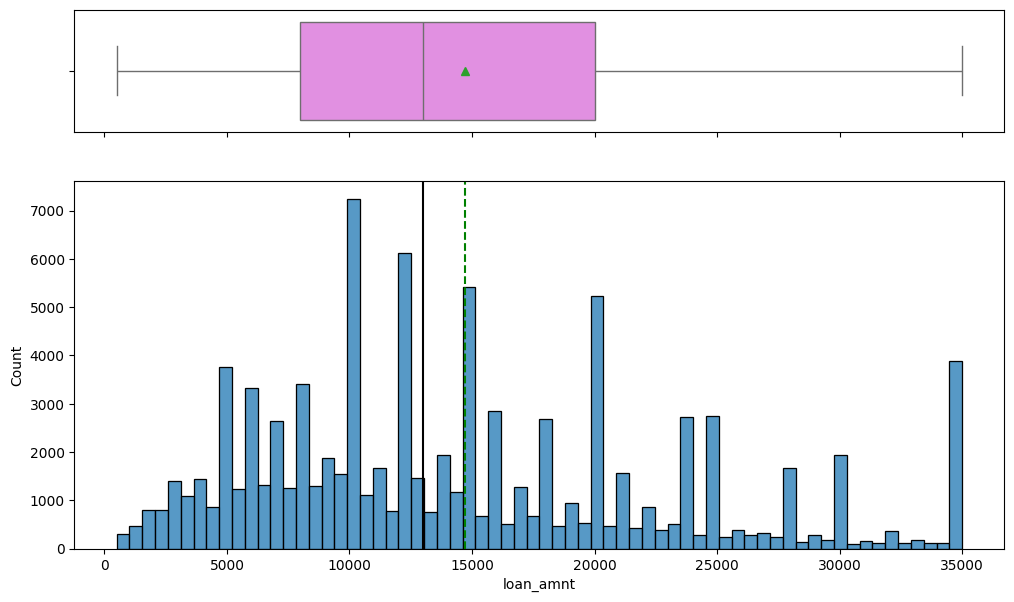

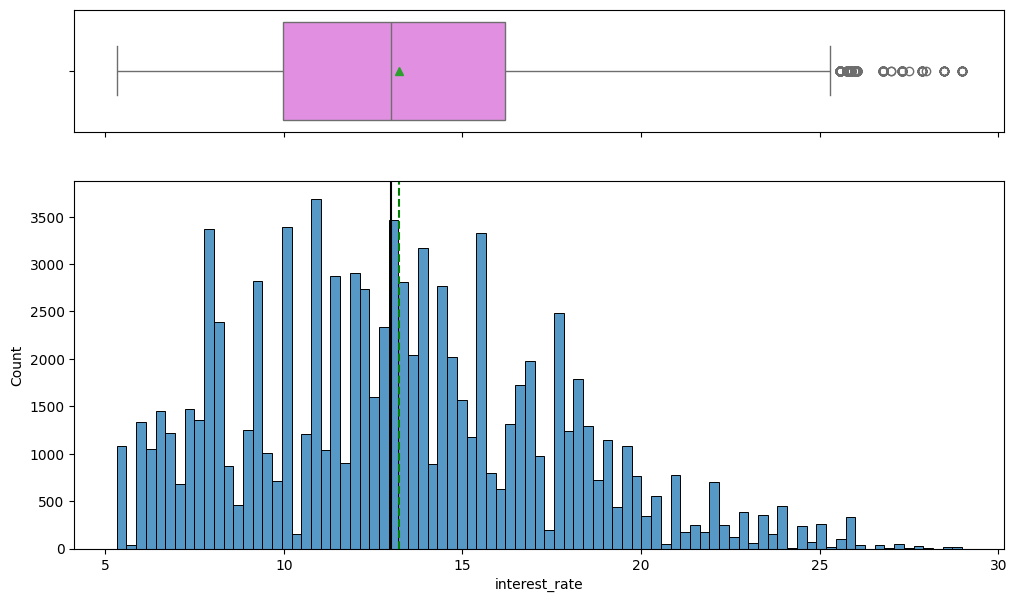

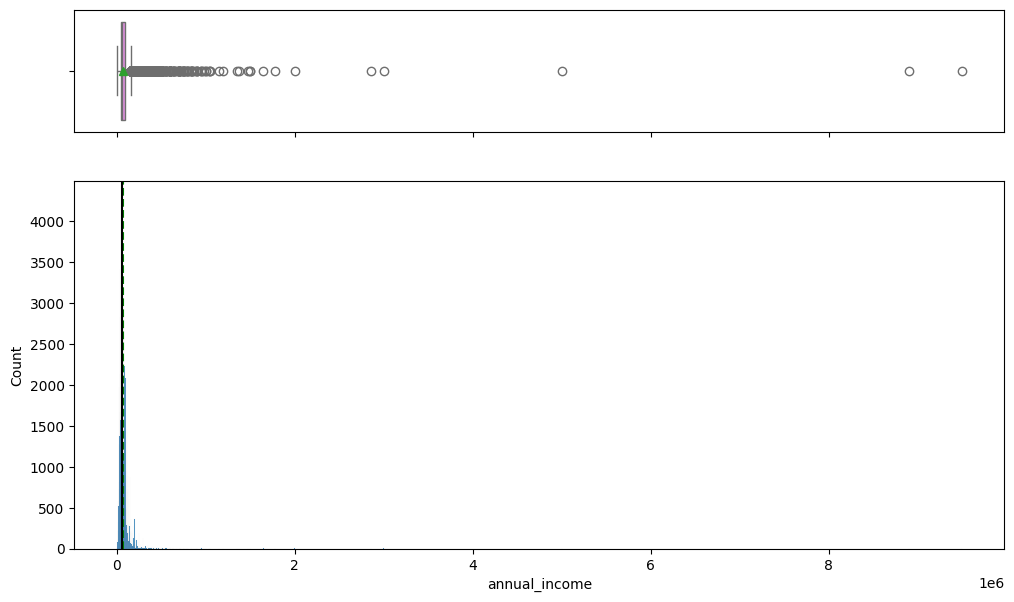

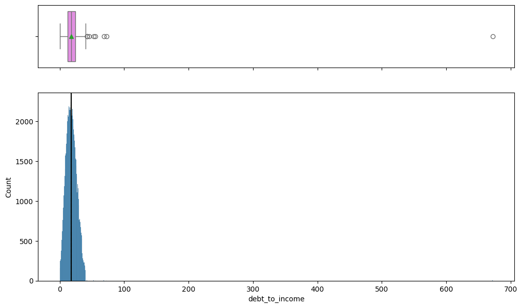

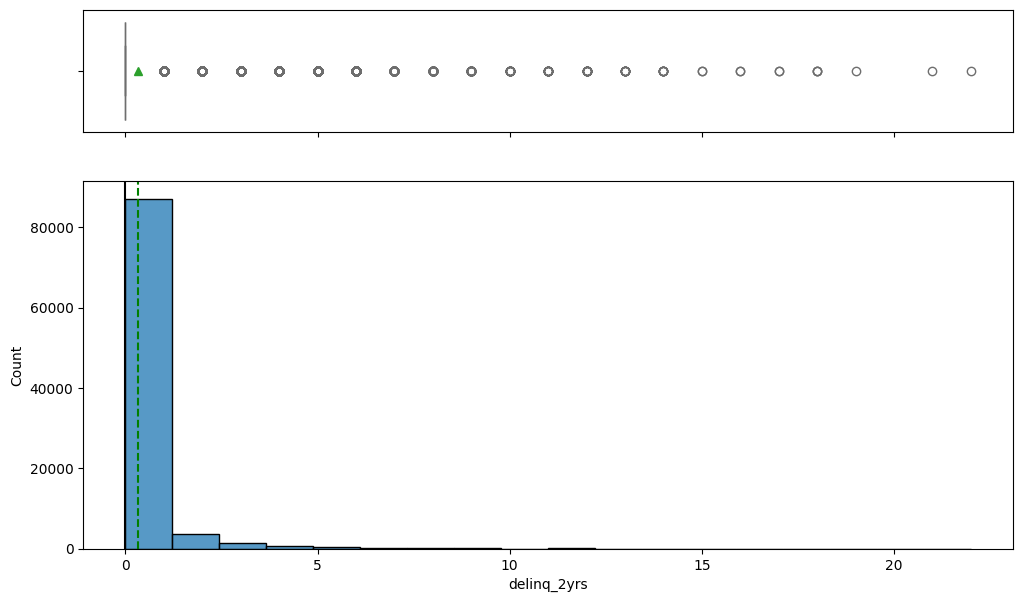

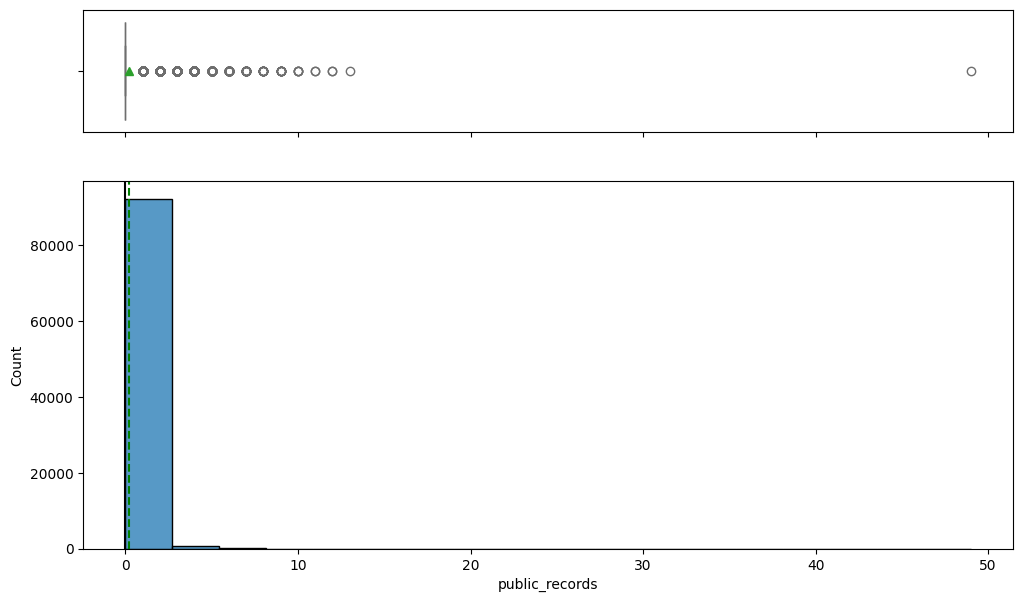

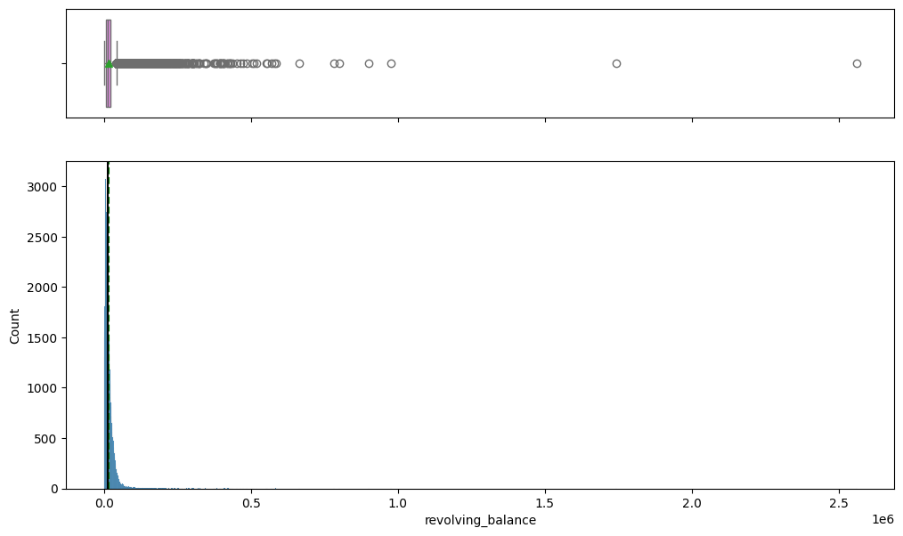

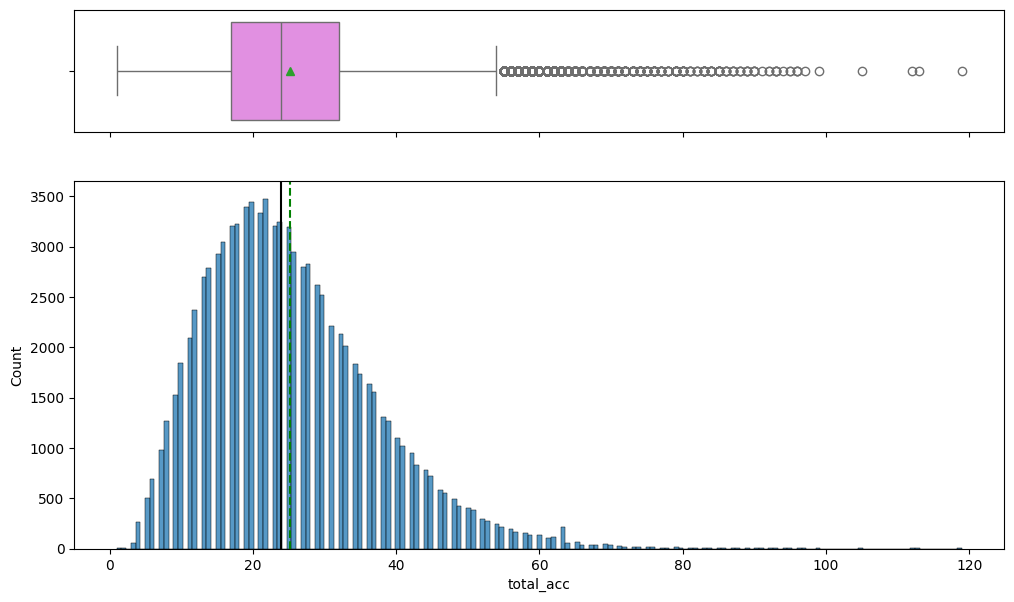

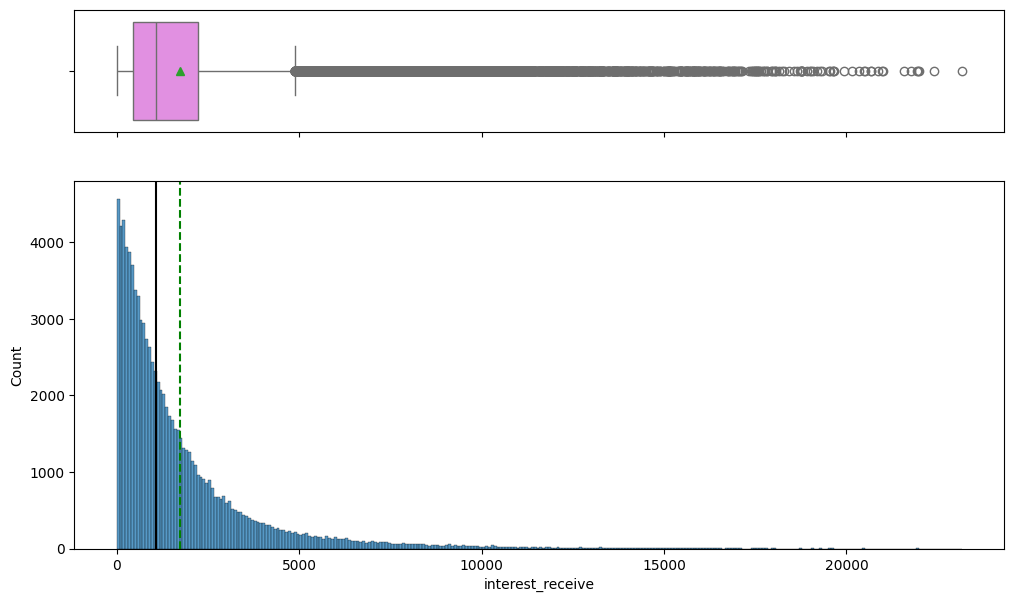

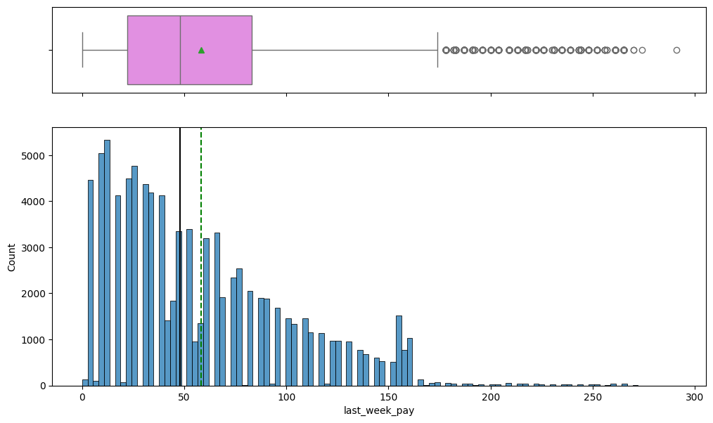

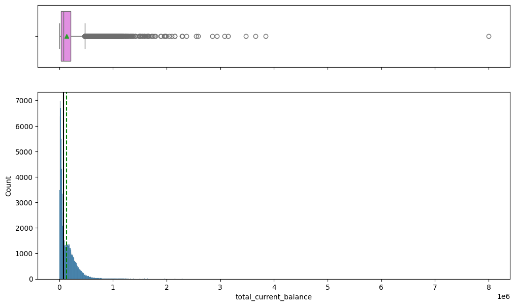

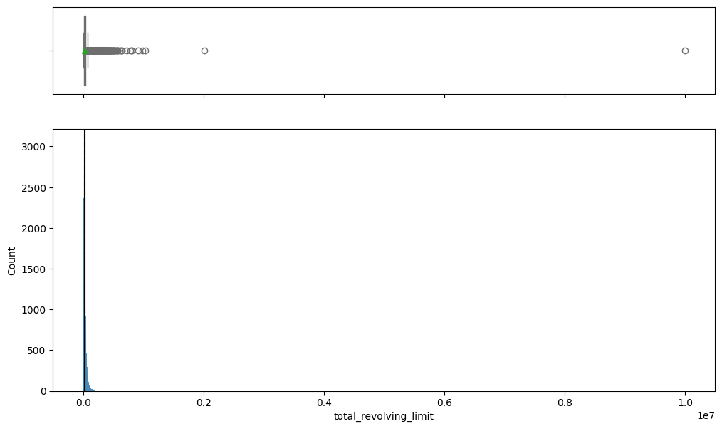

```python
# Apply histogram_boxplot function to each numerical column
for var in numerical_cols:
        histogram_boxplot(df, var, figsize=(12, 7), kde=False, bins=None)
```

**Univariate analysis of numerical variables in test set**

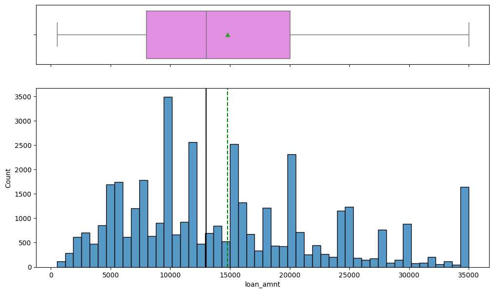

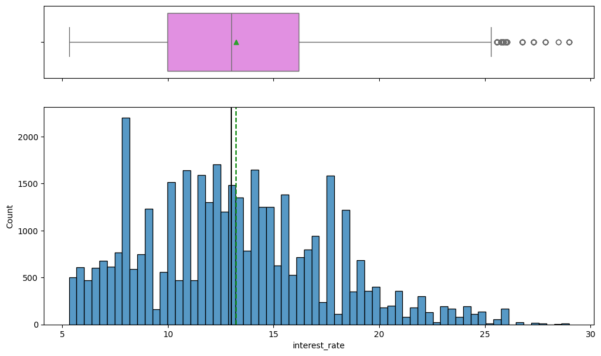

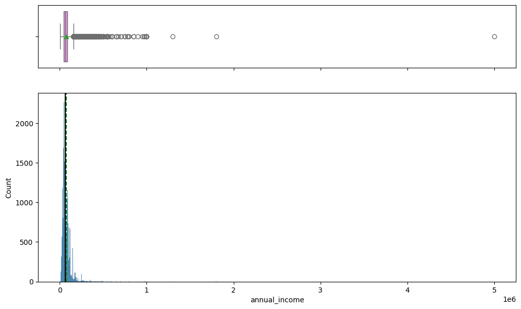

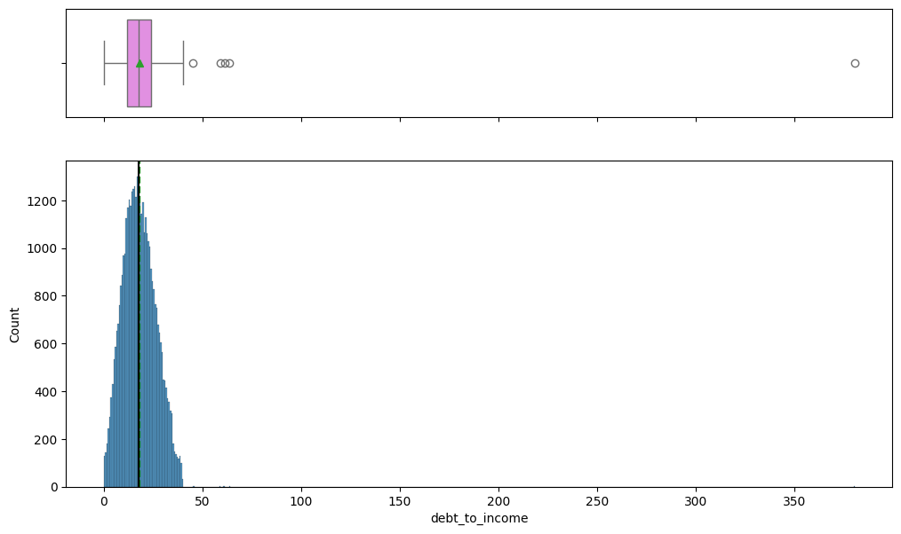

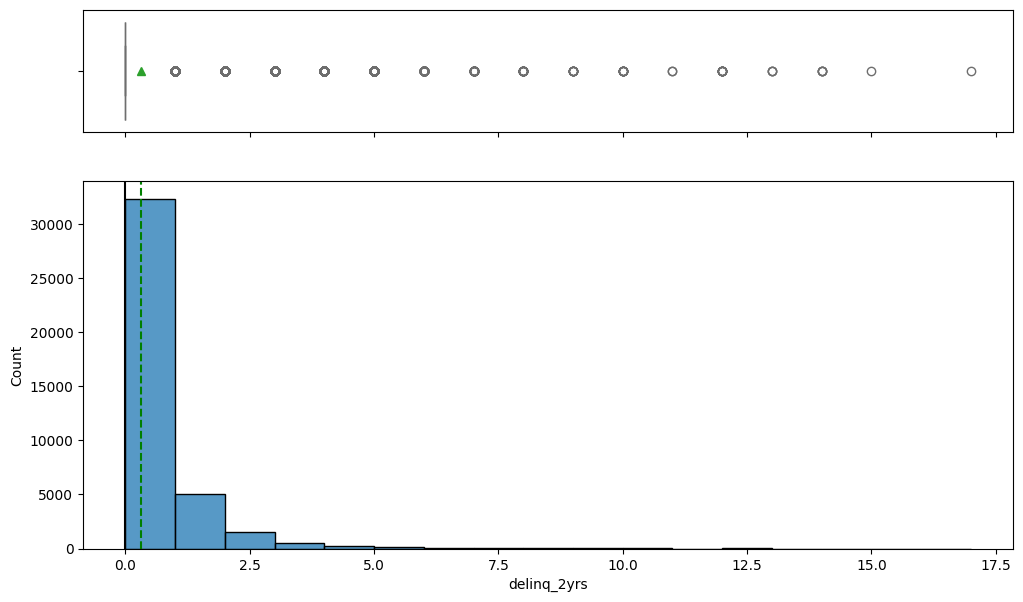

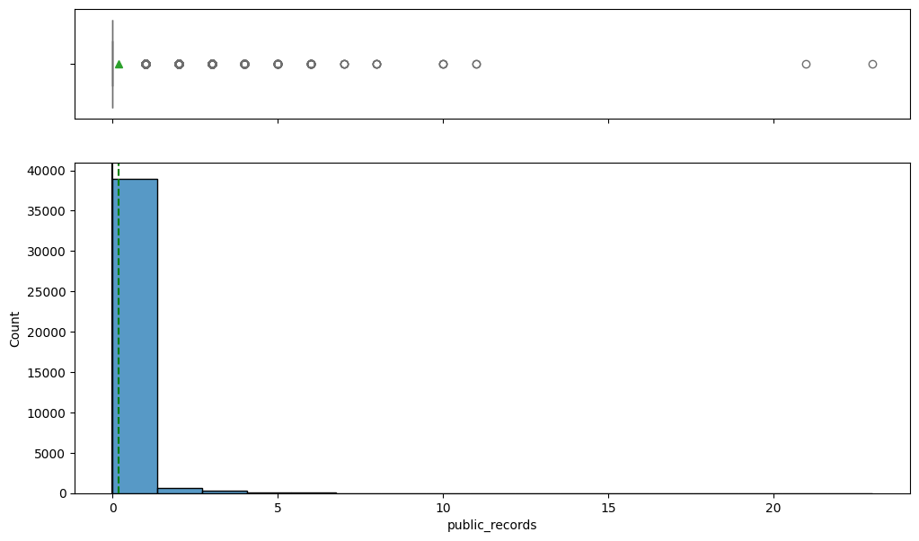

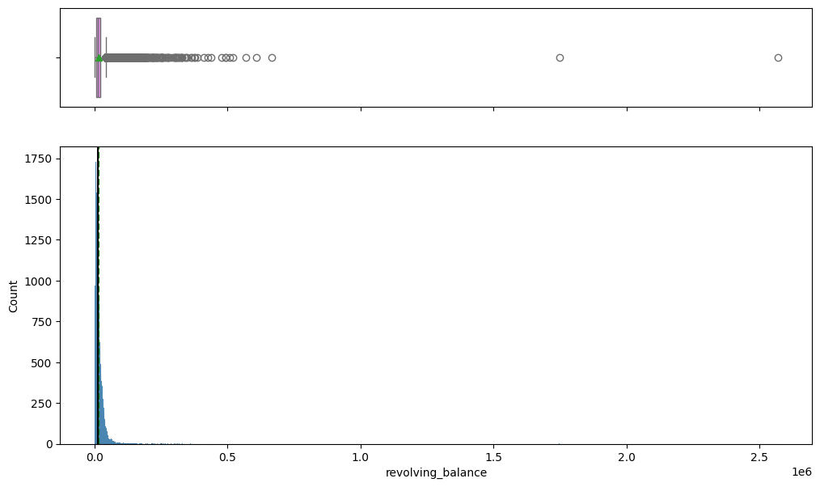

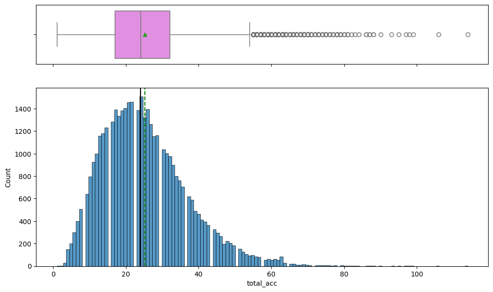

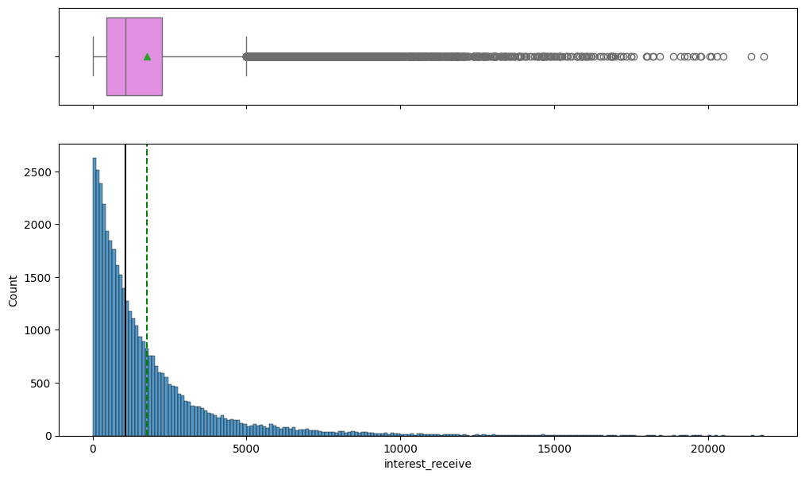

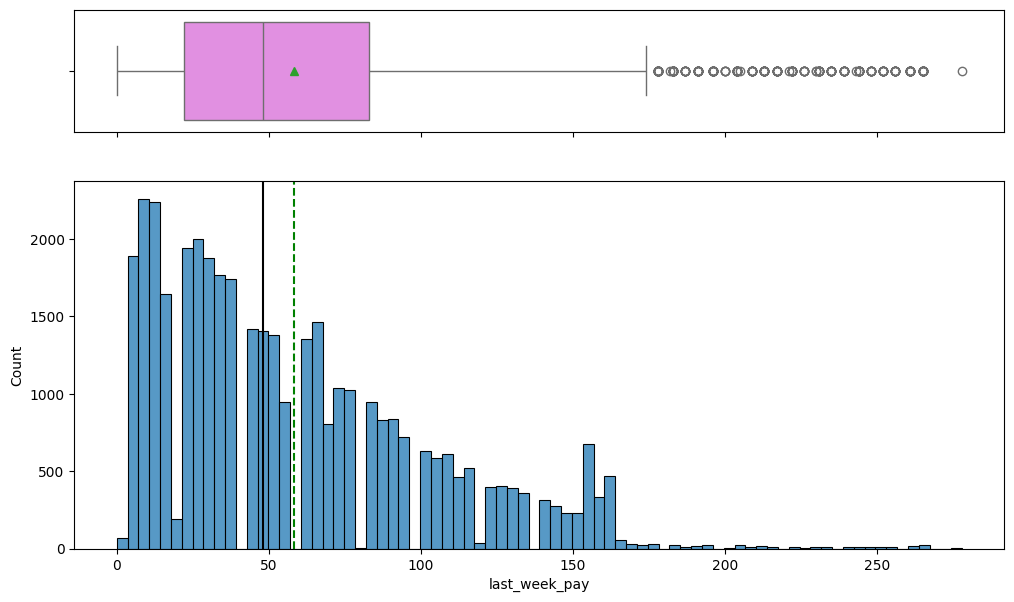

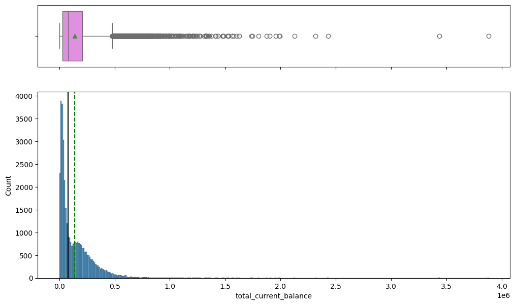

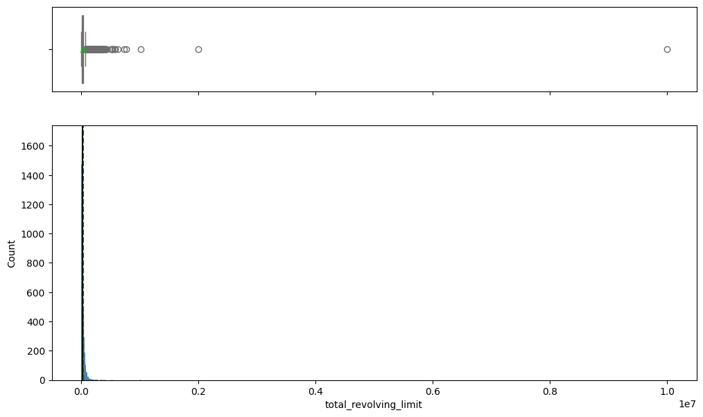

```python
# Exclude 'default' from numerical columss
numerical_cols = [var for var in numerical_cols if var != 'default']

# Apply histogram_boxplot function to each numerical column
for var in numerical_cols:
        histogram_boxplot(df1, var, figsize=(12, 7), kde=False, bins=None)
```